# Advanced Analytics

## #SquadGoals

Julia Romero  
AXA US  
Legacy Analytics

# Reference Info

All data presented here is synthetic and has been generated using:

- the dataset generation tools in [scikit learn](http://scikit-learn.org/stable/datasets/index.html#)
- functions and random number generators

All the code required to perform the examples presented here as well as the presentation itself can be found my a repo on [github](https://github.com/JuliaKR-10/seac_adv_analytics). The link is availible in the presentation documents shared

## Toolbox

Throughout the presentation I will include "toolbox" references highlighting the particular packages I'm using to do something.

All of the examples today are written using [python 3](https://www.python.org/) I am presenting using a [jupyter notebook](https://jupyter.org/) and the RISE Reveal.js extension

## A note on data validation

# CRITICALLY IMPORTANT

### Just not a part of this talk

```python
HTML( "<h1>That data science venn diagram ...</h1>")
Image("https://static1.squarespace.com/static/5150aec6e4b0e340ec52710a/t/51525c33e4b0b3e0d10f77ab/1364352052403/Data_Science_VD.png")
```

That data science venn diagram ...

I like this one better

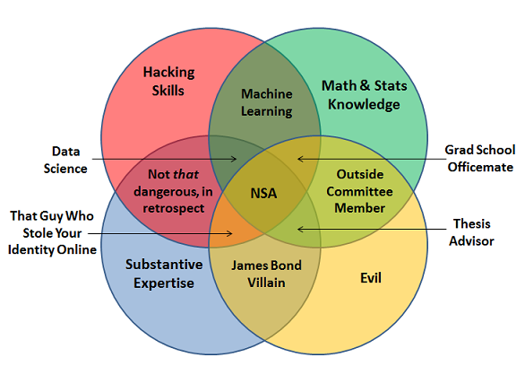

```python
HTML("<h1>I like this one better</h1>")
Image("https://3.bp.blogspot.com/-bvQxcwfqATQ/V-E_uTBc4VI/AAAAAAAAMGQ/Qa1Ntef-rs0E-mWx5pkVu-CPlREdvD0TwCLcB/s1600/VennDiagram2.png")
```

```python
HTML("<h1> ... so why are we here today?</h1><br>")
```

... so why are we here today?

# Move from hype to can

**My goal today is for you to leave this room *knowing* that you can head back to your offices on Monday and with a few emails have an analytics project up and running**

```python
HTML("<h1>One more chart you've seen before</h1><br>")
Image("https://media.licdn.com/mpr/mpr/shrinknp_800_800/AAEAAQAAAAAAAAjIAAAAJGI0NzY3MGM0LTIyMTEtNDYwYy04OWQ2LTgyYmZiNDgzNTlhNw.png")
```

One more chart you've seen before

# Descriptive Analytics

```python
Image("https://media.licdn.com/mpr/mpr/shrinknp_800_800/AAEAAQAAAAAAAAjIAAAAJGI0NzY3MGM0LTIyMTEtNDYwYy04OWQ2LTgyYmZiNDgzNTlhNw.png")
```

## Toolbox

- numpy
- pandas
- matplotlib

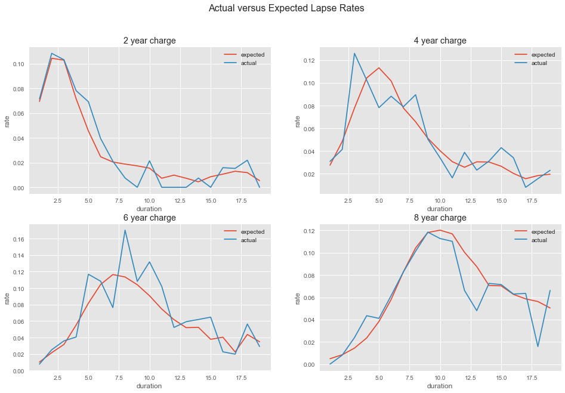

```python
chargePlt(synthExp_gf, ['2','4','6','8'])
```

# Actuaries have been using advance analytics for a long time... we just called it experience

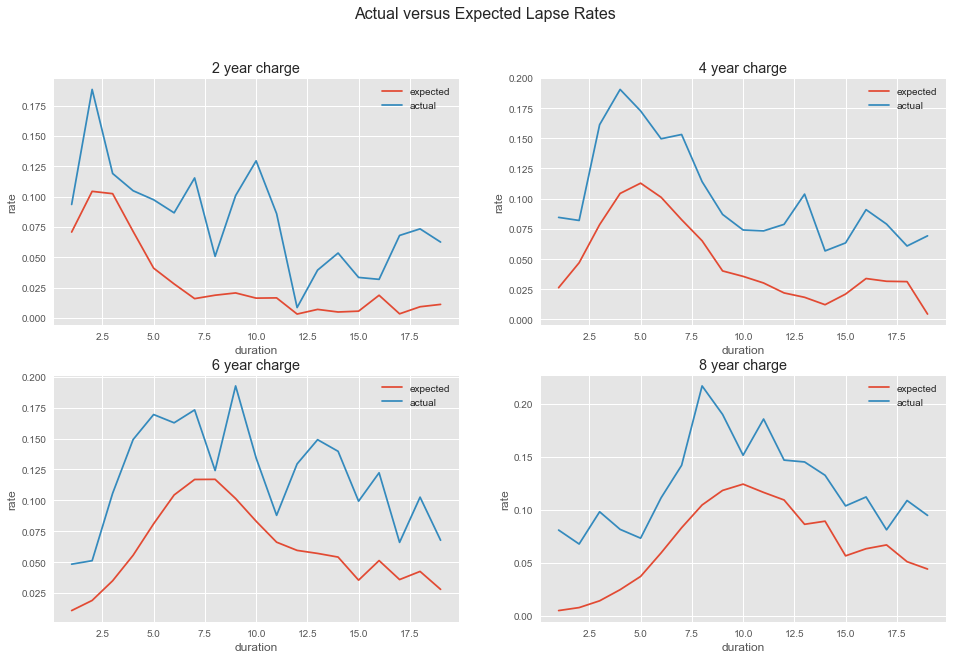

```python
chargePlt(synthExp_ngf, ['2','4','6','8'])
```

# OK fine, but how about something a bit more...

```python
vid = YouTubeVideo("93lrosBEW-Q", start=27, end =40, width = 1067, height = 600, autoplay=0)
display(vid)
```

[video not shown]

```python
HTML("<h2>Remember our trusty old venn diagram</h2><br>")
Image("https://static1.squarespace.com/static/5150aec6e4b0e340ec52710a/t/51525c33e4b0b3e0d10f77ab/1364352052403/Data_Science_VD.png")
```

Remember our trusty old venn diagram

# Diagnostic Analytics

```python
Image("https://media.licdn.com/mpr/mpr/shrinknp_800_800/AAEAAQAAAAAAAAjIAAAAJGI0NzY3MGM0LTIyMTEtNDYwYy04OWQ2LTgyYmZiNDgzNTlhNw.png")
```

# The actuary & the hacker

Actuaries understand product features and the drivers of risk and value

[figure not shown]

```python
HTML("<h3>Actuaries understand product features and the drivers of risk and value</h3> <br>")
Image("images/julia_icon.png")
```

"Hackers" (we'll call them developers from now on) bring a new perspective on how to process and represent data

[figure not shown]

```python
HTML("<h3> \"Hackers\" (we'll call them developers from now on) bring a new perspective on how to process and represent data </h3><br>")
Image("images/eric_icon.png")
```

# Visualization is the most important tool in applied analytics

## How does this relate to "advanced analytics"?

- Visualization is the fastest way to communicate and understand large datasets
- Human beings are hard wired to process images

[figure not shown]

(Credit: XKCD)

## Example: Qualified retirement savings product premium transactions

### Objective question: Why have premium transactions per inforce policy been declining in the last two years?

## Toolbox

- numpy
- pandas
- matplotlib

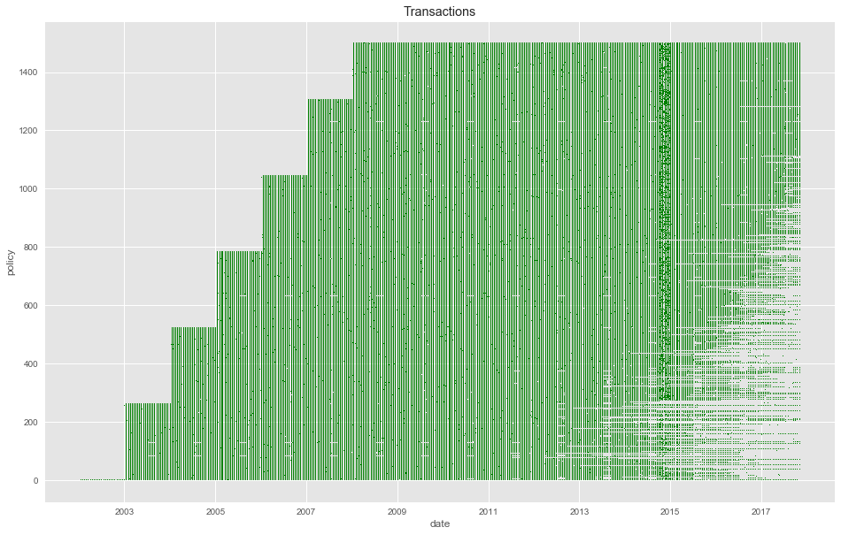

```python
buildFullPremPlt(trxes)
```

[output not shown]

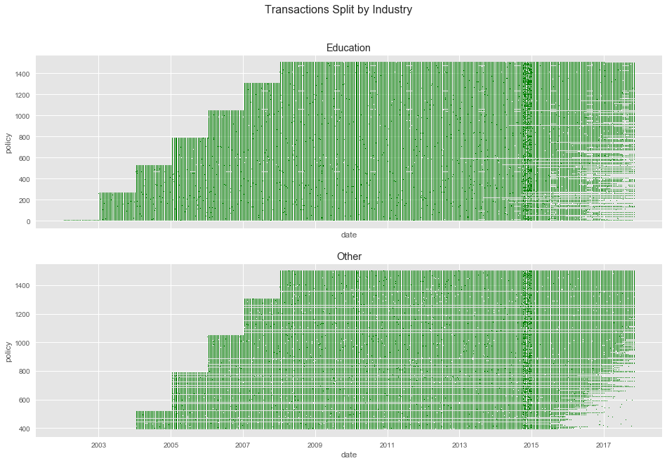

```python
buildIndPremPlt(eduTrx, otherTrx)
```

[output not shown]

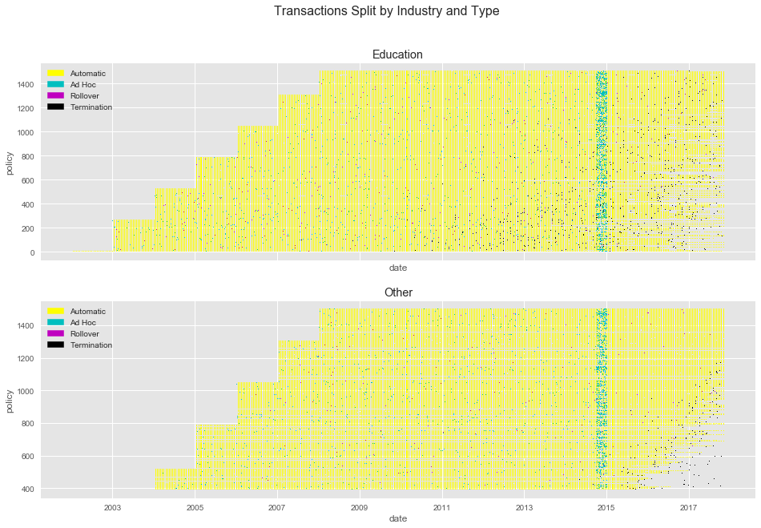

```python
bldIndTypePlt(eduTrx,otherTrx)
```

## The actuary and the hacker help us diagnose the premium decline issue

# Predictive Analytics

```python
Image("https://media.licdn.com/mpr/mpr/shrinknp_800_800/AAEAAQAAAAAAAAjIAAAAJGI0NzY3MGM0LTIyMTEtNDYwYy04OWQ2LTgyYmZiNDgzNTlhNw.png")
```

Adding a substantive expert in the business to your analytics team increases the team's ability to attack relevant business problems and provide on the ground actionable recomendations to end business users

[figure not shown]

```python
HTML("<h3>Adding a substantive expert in the business to your analytics team increases the team's ability to attack relevant business problems and provide on the ground actionable recomendations to end business users</h3>")
Image("images/rob_icon.png")
```

## Example: Expand life insurance sales in diabetes market

#### Business question:

- Which potential clients have the best health / mortality outlooks?
- Can we sell them life insurance?

#### Analytics questions:

- Can we use data to segment our potential client base to find areas where diabetes is "under control"?
- Can we predict applicants that will be better risks?

## Toolbox

- numpy
- pandas
- matplotlib
- sklearn

## Data preperation

**Data Validation and Feature Engineering**

```python
diabetes_df['age_sex_cross'] = diabetes_df.age * diabetes_df.sex
diabetes_df['diseaseStatus_cat'] = diabetes_df.apply(lambda x: cat_Status(x.disease_status_t1), axis = 1)
```

## Build the model

### Model selection

**Describe what you are trying to predict**

- category
- value

**What are you going to do with your predictions?**

### K-nearest Neighbors

- Supervised classification model
- "Looks like"

```python
from sklearn import neighbors
from sklearn.metrics import confusion_matrix
clf =  neighbors.KNeighborsClassifier(15, weights='uniform')
```

### Feature selection

**What goes in the model?**

```python
HTML("<h4>Correlation matrix</h4>")
diabetes_df.corr().style
```

Correlation matrix

|  | age | sex | bmi | avg_bp | s1 | s2 | s3 | s4 | s5 | s6 | disease_status_t1 | age_sex_cross |
| --- | --- | --- | --- | --- | --- | --- | --- | --- | --- | --- | --- | --- |
| age | 1 | 0.173737 | 0.185085 | 0.335427 | 0.260061 | 0.219243 | -0.075181 | 0.203841 | 0.270777 | 0.301731 | 0.187889 | -0.0285763 |
| sex | 0.173737 | 1 | 0.0881614 | 0.241013 | 0.0352768 | 0.142637 | -0.37909 | 0.332115 | 0.149918 | 0.208133 | 0.043062 | 0.0224381 |
| bmi | 0.185085 | 0.0881614 | 1 | 0.395415 | 0.249777 | 0.26117 | -0.366811 | 0.413807 | 0.446159 | 0.38868 | 0.58645 | -0.0605078 |
| avg_bp | 0.335427 | 0.241013 | 0.395415 | 1 | 0.24247 | 0.185558 | -0.178761 | 0.257653 | 0.393478 | 0.390429 | 0.441484 | -0.0725035 |
| s1 | 0.260061 | 0.0352768 | 0.249777 | 0.24247 | 1 | 0.896663 | 0.0515194 | 0.542207 | 0.515501 | 0.325717 | 0.212022 | -0.116381 |
| s2 | 0.219243 | 0.142637 | 0.26117 | 0.185558 | 0.896663 | 1 | -0.196455 | 0.659817 | 0.318353 | 0.2906 | 0.174054 | -0.0753236 |
| s3 | -0.075181 | -0.37909 | -0.366811 | -0.178761 | 0.0515194 | -0.196455 | 1 | -0.738493 | -0.398577 | -0.273697 | -0.394789 | -0.0392564 |
| s4 | 0.203841 | 0.332115 | 0.413807 | 0.257653 | 0.542207 | 0.659817 | -0.738493 | 1 | 0.617857 | 0.417212 | 0.430453 | -0.0461077 |
| s5 | 0.270777 | 0.149918 | 0.446159 | 0.393478 | 0.515501 | 0.318353 | -0.398577 | 0.617857 | 1 | 0.46467 | 0.565883 | -0.0986936 |
| s6 | 0.301731 | 0.208133 | 0.38868 | 0.390429 | 0.325717 | 0.2906 | -0.273697 | 0.417212 | 0.46467 | 1 | 0.382483 | -0.0825197 |
| disease_status_t1 | 0.187889 | 0.043062 | 0.58645 | 0.441484 | 0.212022 | 0.174054 | -0.394789 | 0.430453 | 0.565883 | 0.382483 | 1 | 0.0569693 |
| age_sex_cross | -0.0285763 | 0.0224381 | -0.0605078 | -0.0725035 | -0.116381 | -0.0753236 | -0.0392564 | -0.0461077 | -0.0986936 | -0.0825197 | 0.0569693 | 1 |

### Train the model!

Teach the model how to predict what we want it to predict

```python
clf.fit(X_train[['s5','bmi','s4']], y_train['diseaseStatus_cat'])
```

```
KNeighborsClassifier(algorithm='auto', leaf_size=30, metric='minkowski',
           metric_params=None, n_jobs=1, n_neighbors=15, p=2,
           weights='uniform')
```

# Model Validation

## Sidebar: What is model validation and why should we do it?

Split the dataset and pick a metric

So you can see how well your model did

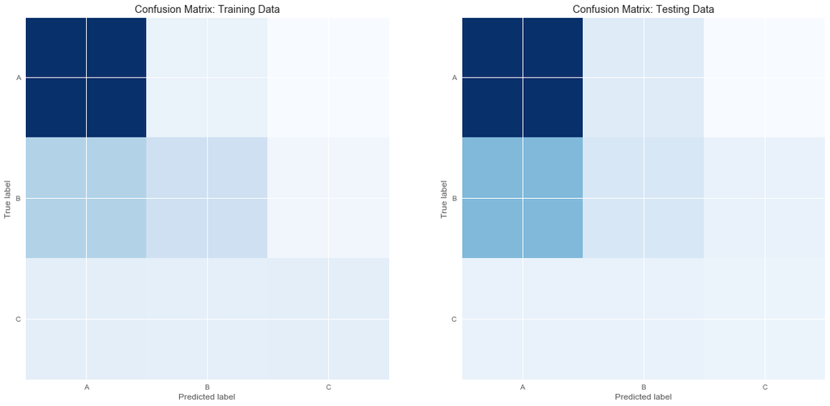

```python
fig, axes = plt.subplots(ncols=2, nrows=1, figsize = (20,16))
ax1, ax2 = axes.ravel()

buildConfusionMatrix(cm_train, classes = class_names, ax = ax1, title = 'Confusion Matrix: Training Data')
buildConfusionMatrix(cm_test, classes = class_names, ax = ax2, title = 'Confusion Matrix: Testing Data')
```

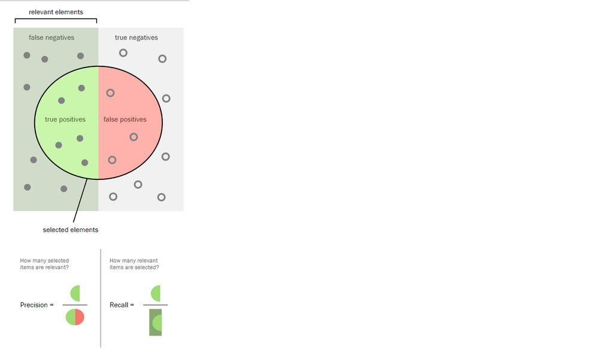

By Walber - Own work, CC BY-SA 4.0, https://commons.wikimedia.org/w/index.php?curid=36926283

```python
Image("images/precision_recall.png")
HTML("By Walber - Own work, CC BY-SA 4.0, https://commons.wikimedia.org/w/index.php?curid=36926283")
```

```python
from sklearn.metrics import precision_score, recall_score
'Precision: {0:%} Recall: {1:%}'.format(
    precision_score(y_test['diseaseStatus_cat'],clf.predict(X_test[['s5','bmi','s4']]), average = 'weighted'),
    recall_score(y_test['diseaseStatus_cat'],clf.predict(X_test[['s5','bmi','s4']]), average = 'weighted'))
```

```
'Precision: 53.305317% Recall: 57.142857%'
```

# The process is iterative!

- Explore different models
- Explore features
- Engineer new features
- Enrich your dataset

### Use business expertise

Our business expert tells us that, underwriters and physicians view blood pressure as a very good predictor of how well a person is managing their overall health

```python
HTML("<h2>Add BP to the predictors!</h2>")
clf2 =  neighbors.KNeighborsClassifier(15, weights='uniform')
clf2.fit(X_train[['s5','bmi','s4','avg_bp']], y_train['diseaseStatus_cat'])

cm_train = confusion_matrix(y_train['diseaseStatus_cat'],clf2.predict(X_train[['s5','bmi','s4','avg_bp']]))
cm_test = confusion_matrix(y_test['diseaseStatus_cat'],clf2.predict(X_test[['s5','bmi','s4','avg_bp']]))
```

Add BP to the predictors!

[output not shown]

## Yes I know... explanatory variables are not free!

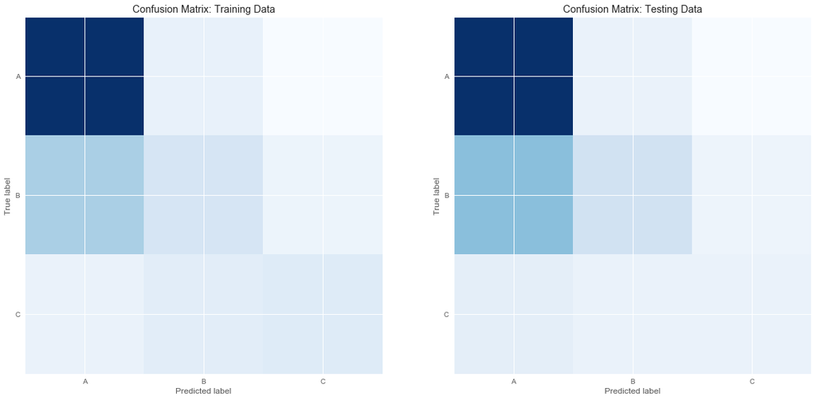

```python
fig, axes = plt.subplots(ncols=2, nrows=1, figsize = (20,16))
ax1, ax2 = axes.ravel()

buildConfusionMatrix(cm_train, classes = class_names, ax = ax1, title = 'Confusion Matrix: Training Data')
buildConfusionMatrix(cm_test, classes = class_names, ax = ax2, title = 'Confusion Matrix: Testing Data')
```

```python
from sklearn.metrics import precision_score, recall_score
'Precision: {0:%} Recall: {1:%}'.format(
    precision_score(y_test['diseaseStatus_cat'],clf2.predict(X_test[['s5','bmi','s4','avg_bp']]), average = 'weighted'),
    recall_score(y_test['diseaseStatus_cat'],clf2.predict(X_test[['s5','bmi','s4','avg_bp']]), average = 'weighted'))
```

```
'Precision: 60.214122% Recall: 62.406015%'
```

## Predictive analytics requires math, coding, and an understanding of business problems

# Prescriptive analytics and beyond

```python
Image("https://media.licdn.com/mpr/mpr/shrinknp_800_800/AAEAAQAAAAAAAAjIAAAAJGI0NzY3MGM0LTIyMTEtNDYwYy04OWQ2LTgyYmZiNDgzNTlhNw.png")
```

Good prescriptive analytics requires a skilled and effective analytics team

[figure not shown]

```python
HTML("<h3>Good prescriptive analytics requires a skilled and effective analytics team </h3>")
Image("images/analyticsteam.png")
```

... it also requires allies

[figure not shown]

```python
HTML("<h3>... it also requires allies</h3>")
Image("images/allies.png")
```

# Prescriptive Analytics Models

- Extension of predictive models
- Artificial or augmented intelligence
- System dynamics or agent based models
- ...

# Agent Based Simulation Models (ABMs)

## What is an agent based model?

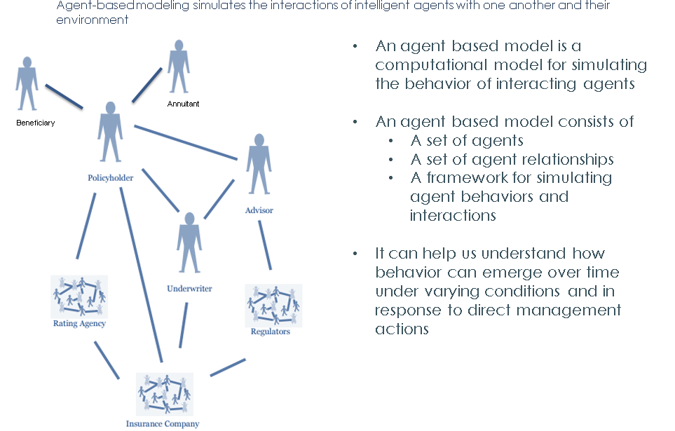

```python
Image("images/ABMs.png")
```

## What do you do with an agent based model?

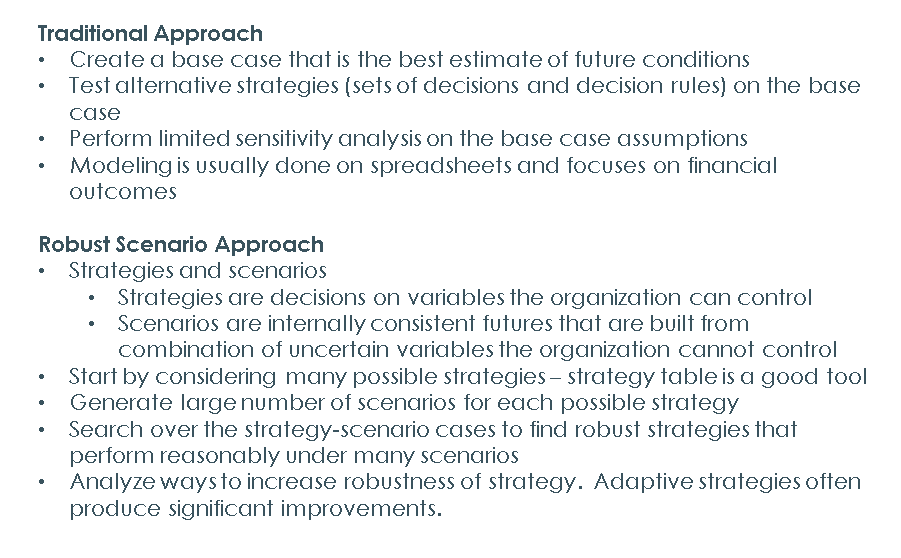

```python
Image("images/usingABMs.png")
```

## When does it make sense to use an agent based model?

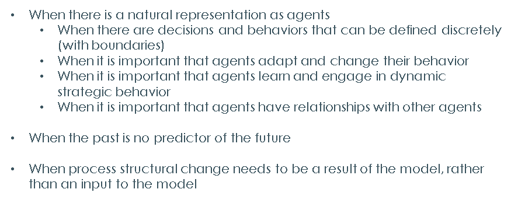

```python
Image("images/whenABM.png")
```

```python
Image("https://media.licdn.com/mpr/mpr/shrinknp_800_800/AAEAAQAAAAAAAAjIAAAAJGI0NzY3MGM0LTIyMTEtNDYwYy04OWQ2LTgyYmZiNDgzNTlhNw.png")
```

```python
Image("https://static1.squarespace.com/static/5150aec6e4b0e340ec52710a/t/51525c33e4b0b3e0d10f77ab/1364352052403/Data_Science_VD.png")
```

[figure not shown]

```python
Image("images/analyticsteam.png")
```